# STA 5703 Project 2 - Submission-Ready R Markdown

Group 6: Cristhian Cruz, Julian McKinley, Luisa Ribeiro, Matheus Lucena

2026-03-11

# 1 Project goal

This file is organized to match the Project Presentation #2 rubric. The response variable is **house sale price**, and because price is strongly right-skewed, the regression models are fit on **log(price)** and then evaluated back on the original **price** scale using RMSE and test-set $R^2$.

The main goals are:

1. compare **best subset selection** and **stepwise selection**;
2. fit **ridge** and **lasso** using **5-fold cross-validation**;
3. compare model performance on a held-out test set;
4. justify a final model choice while discussing complexity and overfitting.

# 2 1. Setup and data preparation

```r
suppressPackageStartupMessages({
  library(tidyverse)
  library(caret)
  library(MASS)
  library(leaps)
  library(glmnet)
  library(broom)
  library(knitr)
})

set.seed(5703)
```

```r
df_raw <- read.csv("kc_house_data.csv")
str(df_raw)
```

```
## 'data.frame':    21613 obs. of  21 variables:
##  $ id           : num  7.13e+09 6.41e+09 5.63e+09 2.49e+09 1.95e+09 ...
##  $ date         : chr  "20141013T000000" "20141209T000000" "20150225T000000" "20141209T000000" ...
##  $ price        : num  221900 538000 180000 604000 510000 ...
##  $ bedrooms     : int  3 3 2 4 3 4 3 3 3 3 ...
##  $ bathrooms    : num  1 2.25 1 3 2 4.5 2.25 1.5 1 2.5 ...
##  $ sqft_living  : int  1180 2570 770 1960 1680 5420 1715 1060 1780 1890 ...
##  $ sqft_lot     : int  5650 7242 10000 5000 8080 101930 6819 9711 7470 6560 ...
##  $ floors       : num  1 2 1 1 1 1 2 1 1 2 ...
##  $ waterfront   : int  0 0 0 0 0 0 0 0 0 0 ...
##  $ view         : int  0 0 0 0 0 0 0 0 0 0 ...
##  $ condition    : int  3 3 3 5 3 3 3 3 3 3 ...
##  $ grade        : int  7 7 6 7 8 11 7 7 7 7 ...
##  $ sqft_above   : int  1180 2170 770 1050 1680 3890 1715 1060 1050 1890 ...
##  $ sqft_basement: int  0 400 0 910 0 1530 0 0 730 0 ...
##  $ yr_built     : int  1955 1951 1933 1965 1987 2001 1995 1963 1960 2003 ...
##  $ yr_renovated : int  0 1991 0 0 0 0 0 0 0 0 ...
##  $ zipcode      : int  98178 98125 98028 98136 98074 98053 98003 98198 98146 98038 ...
##  $ lat          : num  47.5 47.7 47.7 47.5 47.6 ...
##  $ long         : num  -122 -122 -122 -122 -122 ...
##  $ sqft_living15: int  1340 1690 2720 1360 1800 4760 2238 1650 1780 2390 ...
##  $ sqft_lot15   : int  5650 7639 8062 5000 7503 101930 6819 9711 8113 7570 ...
```

```r
# Convert categorical predictors to factors
# and create the log-transformed outcome used in modeling.
df <- df_raw %>%
  mutate(
    zipcode = factor(zipcode),
    waterfront = factor(waterfront),
    view = factor(view),
    condition = factor(condition),
    grade = factor(grade),
    log_price = log(price)
  )
```

```r
# Check for perfect multicollinearity before modeling.
alias_obj <- alias(lm(log_price ~ ., data = df))
redundant_cols <- rownames(alias_obj$Complete)
redundant_cols
```

```
## [1] "sqft_basement"
```

```r
# Drop identifiers and any aliased columns.
drop_cols <- intersect(names(df), c("id", "date", redundant_cols))
df_model <- df %>% dplyr::select(-dplyr::all_of(drop_cols))

names(df_model)
```

```
##  [1] "price"         "bedrooms"      "bathrooms"     "sqft_living"
##  [5] "sqft_lot"      "floors"        "waterfront"    "view"
##  [9] "condition"     "grade"         "sqft_above"    "yr_built"
## [13] "yr_renovated"  "zipcode"       "lat"           "long"
## [17] "sqft_living15" "sqft_lot15"    "log_price"
```

```r
# 80/20 train-test split
idx <- createDataPartition(df_model$log_price, p = 0.80, list = FALSE)
train_df <- df_model[idx, , drop = FALSE]
test_df  <- df_model[-idx, , drop = FALSE]

cat("Train rows:", nrow(train_df), "\n")
cat("Test rows:", nrow(test_df), "\n")
```

```
## Train rows: 17292
## Test rows: 4321
```

## 2.1 1.1 Target encoding for zipcode

`zipcode` has many levels, so for subset-selection methods we replace it with a **training-only target-encoded feature** named `zipcode_log_median`. This preserves location information while avoiding a very large set of dummy variables. The encoding is learned from the training set only to avoid leakage.

```r
zip_medians <- train_df %>%
  group_by(zipcode) %>%
  summarize(zipcode_log_median = median(log_price), .groups = "drop")

train_df <- train_df %>% left_join(zip_medians, by = "zipcode")
test_df  <- test_df  %>% left_join(zip_medians, by = "zipcode")

overall_train_log_median <- median(train_df$log_price)

test_df <- test_df %>%
  mutate(
    zipcode_log_median = if_else(
      is.na(zipcode_log_median),
      overall_train_log_median,
      zipcode_log_median
    )
  )

summary(train_df$zipcode_log_median)
summary(test_df$zipcode_log_median)
```

```
##    Min. 1st Qu.  Median    Mean 3rd Qu.    Max.
##   12.37   12.74   13.00   13.02   13.25   14.46
##    Min. 1st Qu.  Median    Mean 3rd Qu.    Max.
##   12.37   12.74   13.00   13.02   13.25   14.46
```

```r
# Remove the original zipcode after encoding.
df_model <- df %>% dplyr::select(-dplyr::all_of(drop_cols))
train_df <- train_df %>% dplyr::select(-zipcode)
test_df  <- test_df  %>% dplyr::select(-zipcode)
```

## 2.2 1.2 Helper functions

```r
# Evaluate predictions on the original price scale.
price_metrics <- function(pred_log, actual_price) {
  pred_price <- exp(as.numeric(pred_log))
  rmse <- sqrt(mean((actual_price - pred_price)^2))
  r2 <- 1 - sum((actual_price - pred_price)^2) /
    sum((actual_price - mean(actual_price))^2)

  tibble(RMSE = rmse, R2 = r2)
}

# Nice printing wrapper for console output.
print_price_metrics <- function(model_name, pred_log, actual_price) {
  out <- price_metrics(pred_log, actual_price)
  cat(model_name, "\n")
  cat("RMSE:", round(out$RMSE, 3), "\n")
  cat("R^2:", round(out$R2, 6), "\n\n")
  invisible(out)
}

# Extract the original term names selected by regsubsets.
# This supports the all-or-nothing treatment of factors.
extract_selected_terms <- function(selected_dummies, data) {
  mm <- model.matrix(log_price ~ . - price, data = data)
  mm_terms <- attr(terms(log_price ~ . - price, data = data), "term.labels")
  mm_assign <- attr(mm, "assign")[-1]
  mm_names <- colnames(mm)[-1]

  dummy_map <- tibble(
    dummy = mm_names,
    term_index = mm_assign,
    term = mm_terms[mm_assign]
  )

  unique(dummy_map$term[dummy_map$dummy %in% selected_dummies])
}

# Helper to display the largest coefficients.
extract_top_coefs <- function(coef_object, top_n = 12) {
  tibble(
    term = rownames(as.matrix(coef_object)),
    estimate = as.numeric(coef_object)
  ) %>%
    filter(term != "(Intercept)") %>%
    arrange(desc(abs(estimate))) %>%
    slice_head(n = top_n)
}
```

# 3 2. Best subset selection

Best subset selection performs an exhaustive search over models of different sizes. The rubric specifically asks for **Adjusted** $R^2$, **Mallows** $C_p$, and **BIC**, so those metrics are computed and plotted below.

```r
# Number of candidate predictors after dummy encoding (excluding intercept).
p <- ncol(model.matrix(log_price ~ . - price, data = train_df)) - 1

best_fit <- regsubsets(
  log_price ~ . - price,
  data = train_df,
  nvmax = p,
  method = "exhaustive"
)

best_summary <- summary(best_fit)

best_metrics <- tibble(
  size = 1:p,
  adj_r2 = best_summary$adjr2,
  cp = best_summary$cp,
  bic = best_summary$bic
)

best_adjr2 <- which.max(best_summary$adjr2)
best_cp    <- which.min(best_summary$cp)
best_bic   <- which.min(best_summary$bic)

kable(
  tibble(
    Criterion = c("Adjusted R^2", "Cp", "BIC"),
    Best_Model_Size = c(best_adjr2, best_cp, best_bic)
  ),
  digits = 4,
  caption = "Optimal model sizes from best subset selection"
)
```

Optimal model sizes from best subset selection

| Criterion | Best_Model_Size |
| --- | --- |
| Adjusted R^2 | 31 |
| Cp | 31 |
| BIC | 27 |

```r
cat("Regsubsets metrics\n")
cat("Best model size by Adjusted R^2:", best_adjr2, "\n")
cat("Best model size by Cp:", best_cp, "\n")
cat("Best model size by BIC:", best_bic, "\n")
```

```
## Regsubsets metrics
## Best model size by Adjusted R^2: 31
## Best model size by Cp: 31
## Best model size by BIC: 27
```

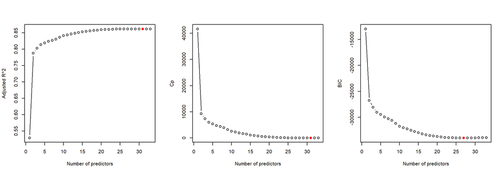

```r
par(mfrow = c(1, 3))

plot(best_metrics$size, best_metrics$adj_r2,
     type = "b", xlab = "Number of predictors", ylab = "Adjusted R^2")
points(best_adjr2, best_metrics$adj_r2[best_adjr2], col = "red", pch = 19)

plot(best_metrics$size, best_metrics$cp,
     type = "b", xlab = "Number of predictors", ylab = "Cp")
points(best_cp, best_metrics$cp[best_cp], col = "red", pch = 19)

plot(best_metrics$size, best_metrics$bic,
     type = "b", xlab = "Number of predictors", ylab = "BIC")
points(best_bic, best_metrics$bic[best_bic], col = "red", pch = 19)
```

```r
par(mfrow = c(1, 1))
```

## 3.1 2.1 Interpretation of Adjusted $R^2$, $C_p$, and BIC

- **Adjusted** $R^2$ rewards model fit but penalizes unnecessary predictors, so higher values are preferred.
- **Mallows** $C_p$ measures the bias-variance tradeoff, so lower values are preferred.
- **BIC** penalizes model size more strongly than Adjusted $R^2$ or $C_p$, so lower values are preferred when the goal is a more parsimonious model.

Because BIC applies the strongest complexity penalty, the **BIC-selected model** is used as the final best-subset candidate for test-set evaluation.

## 3.2 2.2 Refit the BIC-selected subset

The raw `regsubsets()` output is based on dummy-coded columns. To make the final model interpretable, the selected dummy variables are mapped back to their original terms, and factor variables are included using an all-or-nothing rule.

```r
best_bic_coefs <- coef(best_fit, id = best_bic)
selected_dummies <- names(best_bic_coefs)[-1]
selected_terms <- extract_selected_terms(selected_dummies, train_df)

selected_dummies
selected_terms
```

```
##  [1] "bathrooms"          "sqft_living"        "sqft_lot"
##  [4] "floors"             "waterfront1"        "view1"
##  [7] "view2"              "view3"              "view4"
## [10] "condition3"         "condition4"         "condition5"
## [13] "grade6"             "grade7"             "grade8"
## [16] "grade9"             "grade10"            "grade11"
## [19] "grade12"            "grade13"            "sqft_above"
## [22] "yr_built"           "yr_renovated"       "lat"
## [25] "long"               "sqft_living15"      "zipcode_log_median"
##  [1] "bathrooms"          "sqft_living"        "sqft_lot"
##  [4] "floors"             "waterfront"         "view"
##  [7] "condition"          "grade"              "sqft_above"
## [10] "yr_built"           "yr_renovated"       "lat"
## [13] "long"               "sqft_living15"      "zipcode_log_median"
```

```r
formula_bss <- as.formula(
  paste("log_price ~", paste(selected_terms, collapse = " + "))
)

bss_model <- lm(formula_bss, data = train_df)
summary(bss_model)
```

```
##
## Call:
## lm(formula = formula_bss, data = train_df)
##
## Residuals:
##      Min       1Q   Median       3Q      Max
## -1.67371 -0.11179  0.00323  0.11606  1.09317
##
## Coefficients:
##                      Estimate Std. Error t value Pr(>|t|)
## (Intercept)        -5.228e+01  1.733e+00 -30.159  < 2e-16 ***
## bathrooms           5.011e-02  3.510e-03  14.275  < 2e-16 ***
## sqft_living         1.401e-04  4.601e-06  30.443  < 2e-16 ***
## sqft_lot            6.692e-07  3.731e-08  17.935  < 2e-16 ***
## floors              2.121e-02  3.983e-03   5.324 1.03e-07 ***
## waterfront1         3.968e-01  2.228e-02  17.810  < 2e-16 ***
## view1               1.315e-01  1.231e-02  10.682  < 2e-16 ***
## view2               1.320e-01  7.493e-03  17.619  < 2e-16 ***
## view3               1.775e-01  1.025e-02  17.326  < 2e-16 ***
## view4               3.035e-01  1.645e-02  18.451  < 2e-16 ***
## condition2          1.079e-01  4.532e-02   2.380  0.01733 *
## condition3          2.611e-01  4.240e-02   6.158 7.55e-10 ***
## condition4          2.890e-01  4.240e-02   6.817 9.62e-12 ***
## condition5          3.607e-01  4.265e-02   8.458  < 2e-16 ***
## grade3              2.435e-01  2.312e-01   1.053  0.29239
## grade4              6.723e-02  2.053e-01   0.327  0.74336
## grade5              5.488e-02  2.016e-01   0.272  0.78542
## grade6              1.775e-01  2.014e-01   0.881  0.37811
## grade7              3.141e-01  2.014e-01   1.559  0.11891
## grade8              4.167e-01  2.015e-01   2.068  0.03868 *
## grade9              5.250e-01  2.016e-01   2.604  0.00922 **
## grade10             5.840e-01  2.018e-01   2.894  0.00380 **
## grade11             6.083e-01  2.021e-01   3.010  0.00262 **
## grade12             6.466e-01  2.033e-01   3.181  0.00147 **
## grade13             6.531e-01  2.098e-01   3.114  0.00185 **
## sqft_above          4.584e-05  4.830e-06   9.490  < 2e-16 ***
## yr_built           -1.828e-03  8.148e-05 -22.430  < 2e-16 ***
## yr_renovated        2.244e-05  4.066e-06   5.521 3.42e-08 ***
## lat                 4.117e-01  1.449e-02  28.409  < 2e-16 ***
## long               -3.274e-01  1.320e-02 -24.795  < 2e-16 ***
## sqft_living15       4.150e-05  3.828e-06  10.840  < 2e-16 ***
## zipcode_log_median  6.196e-01  5.858e-03 105.771  < 2e-16 ***
## ---
## Signif. codes:  0 '***' 0.001 '**' 0.01 '*' 0.05 '.' 0.1 ' ' 1
##
## Residual standard error: 0.1968 on 17260 degrees of freedom
## Multiple R-squared:  0.862,  Adjusted R-squared:  0.8618
## F-statistic:  3478 on 31 and 17260 DF,  p-value: < 2.2e-16
```

```r
pred_log_bss <- predict(bss_model, newdata = test_df)
bss_test_metrics <- print_price_metrics(
  "Best subset model (BIC-selected) test metrics:",
  pred_log_bss,
  test_df$price
)
```

```
## Best subset model (BIC-selected) test metrics:
## RMSE: 142317.2
## R^2: 0.81607
```

### 3.2.1 Best subset interpretation

The best subset model is expected to keep predictors related to **size**, **quality**, **location**, and **amenities**, which are the dominant drivers of housing price in this dataset. In the presentation, the best BIC model was also the strongest held-out performer, with approximately **RMSE = 142,317** and **test $R^2 = 0.816**. Those results are consistent with a strong but still interpretable model.

# 4 3. Stepwise selection

Stepwise selection is less computationally expensive than exhaustive search because it adds and removes predictors sequentially rather than evaluating every possible combination.

```r
full_model <- lm(log_price ~ . - price, data = train_df)
step_model <- step(full_model, direction = "both", trace = FALSE)

summary(step_model)
```

```
##
## Call:
## lm(formula = log_price ~ (price + bedrooms + bathrooms + sqft_living +
##     sqft_lot + floors + waterfront + view + condition + grade +
##     sqft_above + yr_built + yr_renovated + lat + long + sqft_living15 +
##     sqft_lot15 + zipcode_log_median) - price, data = train_df)
##
## Residuals:
##      Min       1Q   Median       3Q      Max
## -1.68512 -0.11176  0.00287  0.11548  1.09206
##
## Coefficients:
##                      Estimate Std. Error t value Pr(>|t|)
## (Intercept)        -5.196e+01  1.739e+00 -29.883  < 2e-16 ***
## bedrooms           -5.762e-03  2.084e-03  -2.765  0.00570 **
## bathrooms           5.182e-02  3.576e-03  14.489  < 2e-16 ***
## sqft_living         1.437e-04  4.768e-06  30.129  < 2e-16 ***
## sqft_lot            7.174e-07  5.289e-08  13.563  < 2e-16 ***
## floors              2.058e-02  3.988e-03   5.162 2.47e-07 ***
## waterfront1         3.949e-01  2.229e-02  17.712  < 2e-16 ***
## view1               1.304e-01  1.232e-02  10.592  < 2e-16 ***
## view2               1.312e-01  7.499e-03  17.492  < 2e-16 ***
## view3               1.760e-01  1.026e-02  17.165  < 2e-16 ***
## view4               3.019e-01  1.645e-02  18.349  < 2e-16 ***
## condition2          1.084e-01  4.531e-02   2.393  0.01674 *
## condition3          2.620e-01  4.239e-02   6.181 6.50e-10 ***
## condition4          2.904e-01  4.240e-02   6.849 7.68e-12 ***
## condition5          3.620e-01  4.264e-02   8.490  < 2e-16 ***
## grade3              2.461e-01  2.312e-01   1.064  0.28718
## grade4              7.111e-02  2.053e-01   0.346  0.72907
## grade5              6.189e-02  2.016e-01   0.307  0.75882
## grade6              1.856e-01  2.014e-01   0.921  0.35685
## grade7              3.230e-01  2.014e-01   1.603  0.10885
## grade8              4.245e-01  2.015e-01   2.107  0.03513 *
## grade9              5.318e-01  2.016e-01   2.638  0.00834 **
## grade10             5.886e-01  2.017e-01   2.918  0.00353 **
## grade11             6.108e-01  2.021e-01   3.022  0.00251 **
## grade12             6.449e-01  2.033e-01   3.173  0.00151 **
## grade13             6.451e-01  2.097e-01   3.076  0.00210 **
## sqft_above          4.624e-05  4.831e-06   9.572  < 2e-16 ***
## yr_built           -1.848e-03  8.187e-05 -22.574  < 2e-16 ***
## yr_renovated        2.202e-05  4.070e-06   5.410 6.37e-08 ***
## lat                 4.110e-01  1.449e-02  28.361  < 2e-16 ***
## long               -3.255e-01  1.325e-02 -24.569  < 2e-16 ***
## sqft_living15       4.191e-05  3.834e-06  10.932  < 2e-16 ***
## sqft_lot15         -1.213e-07  8.099e-08  -1.498  0.13427
## zipcode_log_median  6.189e-01  5.862e-03 105.577  < 2e-16 ***
## ---
## Signif. codes:  0 '***' 0.001 '**' 0.01 '*' 0.05 '.' 0.1 ' ' 1
##
## Residual standard error: 0.1968 on 17258 degrees of freedom
## Multiple R-squared:  0.8621, Adjusted R-squared:  0.8618
## F-statistic:  3269 on 33 and 17258 DF,  p-value: < 2.2e-16
```

```r
step_coefs <- tidy(step_model) %>%
  filter(term != "(Intercept)") %>%
  arrange(p.value)

kable(
  step_coefs %>% slice_head(n = 12),
  digits = 4,
  caption = "Most statistically significant terms in the stepwise model"
)
```

Most statistically significant terms in the stepwise model

| term | estimate | std.error | statistic | p.value |
| --- | --- | --- | --- | --- |
| zipcode_log_median | 0.6189 | 0.0059 | 105.5772 | 0 |
| sqft_living | 0.0001 | 0.0000 | 30.1294 | 0 |
| lat | 0.4110 | 0.0145 | 28.3607 | 0 |
| long | -0.3255 | 0.0132 | -24.5689 | 0 |
| yr_built | -0.0018 | 0.0001 | -22.5741 | 0 |
| view4 | 0.3019 | 0.0165 | 18.3491 | 0 |
| waterfront1 | 0.3949 | 0.0223 | 17.7118 | 0 |
| view2 | 0.1312 | 0.0075 | 17.4917 | 0 |
| view3 | 0.1760 | 0.0103 | 17.1655 | 0 |
| bathrooms | 0.0518 | 0.0036 | 14.4892 | 0 |
| sqft_lot | 0.0000 | 0.0000 | 13.5634 | 0 |
| sqft_living15 | 0.0000 | 0.0000 | 10.9321 | 0 |

```r
pred_log_step <- predict(step_model, newdata = test_df)
step_test_metrics <- print_price_metrics(
  "Stepwise model test metrics:",
  pred_log_step,
  test_df$price
)
```

```
## Stepwise model test metrics:
## RMSE: 142518
## R^2: 0.81555
```

### 4.0.1 Stepwise interpretation and comparison with best subset

The stepwise model should select many of the same structural and location-based predictors chosen by best subset selection. In the current presentation, the stepwise model emphasizes `zipcode_log_median`, `sqft_living`, `lat`, `long`, `yr_built`, `waterfront`, and higher `view` categories, which is substantively consistent with the best subset story. Its reported held-out performance is also very similar to best subset, with approximately **RMSE = 142,518** and **test $R^2 = 0.8156**.

# 5 4. Regularization with 5-fold cross-validation

Because the response is continuous, the regularization analysis uses **ridge regression** and **lasso regression**. Both are fit with **5-fold cross-validation**, as required by the rubric.

```r
x_train <- model.matrix(log_price ~ . - log_price - price, data = train_df)[, -1]
y_train <- train_df$log_price

x_test <- model.matrix(log_price ~ . - log_price - price, data = test_df)[, -1]
y_test <- test_df$log_price

dim(x_train)
dim(x_test)
```

```
## [1] 17292    33
## [1] 4321   33
```

## 5.1 4.1 Ridge regression

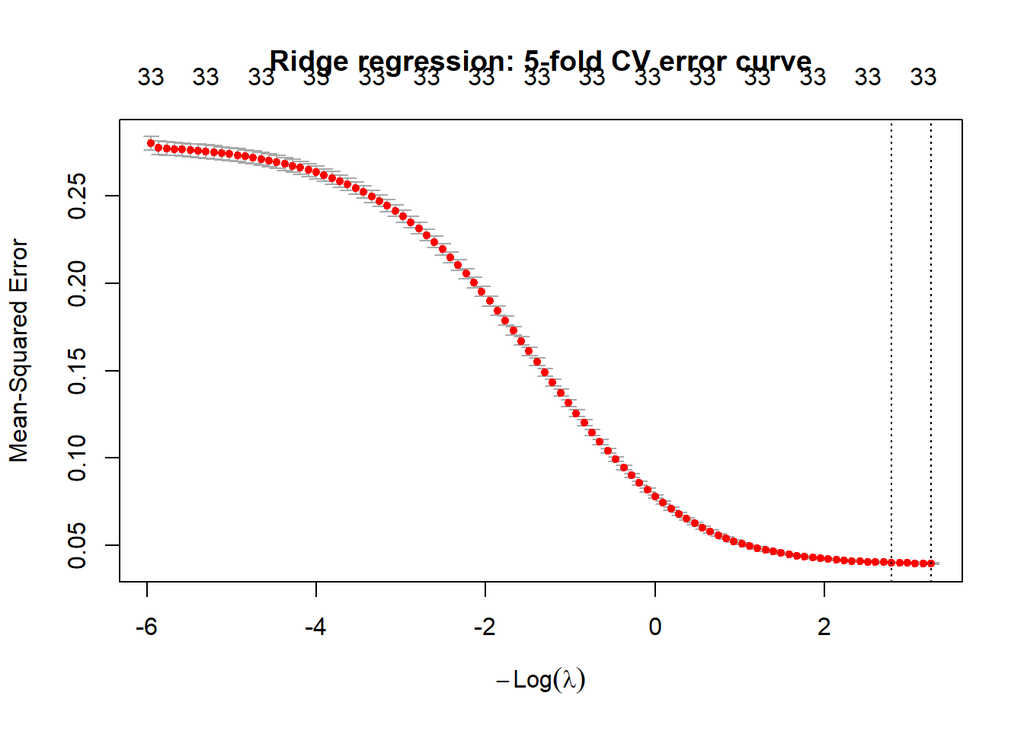

```r
cv_ridge <- cv.glmnet(
  x_train,
  y_train,
  alpha = 0,
  nfolds = 5
)

plot(cv_ridge)
title("Ridge regression: 5-fold CV error curve")
```

```r
ridge_lambda_min <- cv_ridge$lambda.min
ridge_lambda_1se <- cv_ridge$lambda.1se

ridge_lambda_min
ridge_lambda_1se
```

```
## [1] 0.03849023
## [1] 0.06128732
```

```r
ridge_coef_min <- coef(cv_ridge, s = "lambda.min")
ridge_coef_1se <- coef(cv_ridge, s = "lambda.1se")

kable(
  extract_top_coefs(ridge_coef_min, top_n = 12),
  digits = 5,
  caption = "Largest ridge coefficients at lambda.min"
)
```

Largest ridge coefficients at lambda.min

| term | estimate |
| --- | --- |
| zipcode_log_median | 0.56081 |
| lat | 0.48589 |
| waterfront1 | 0.38131 |
| grade5 | -0.31918 |
| grade4 | -0.31429 |
| grade13 | 0.30427 |
| long | -0.30039 |
| view4 | 0.29872 |
| grade12 | 0.27593 |
| grade11 | 0.22713 |
| grade10 | 0.19917 |
| grade6 | -0.19548 |

```r
pred_log_ridge_min <- predict(cv_ridge, s = "lambda.min", newx = x_test)
pred_log_ridge_1se <- predict(cv_ridge, s = "lambda.1se", newx = x_test)

ridge_test_min <- print_price_metrics(
  "Ridge model test metrics (lambda.min):",
  pred_log_ridge_min,
  test_df$price
)

ridge_test_1se <- print_price_metrics(
  "Ridge model test metrics (lambda.1se):",
  pred_log_ridge_1se,
  test_df$price
)
```

```
## Ridge model test metrics (lambda.min):
## RMSE: 142363.5
## R^2: 0.81595
##
## Ridge model test metrics (lambda.1se):
## RMSE: 143053.5
## R^2: 0.814161
```

### 5.1.1 Ridge interpretation

`lambda.min` gives the value of $\lambda$ with the lowest cross-validated error, while `lambda.1se` gives the largest $\lambda$ within one standard error of the minimum. The latter is often preferred when a slightly simpler and more stable model is desired. In the current presentation, ridge at `lambda.min` achieves approximately **RMSE = 142,363** and **test $R^2 = 0.816**, very close to best subset.

## 5.2 4.2 LASSO regression

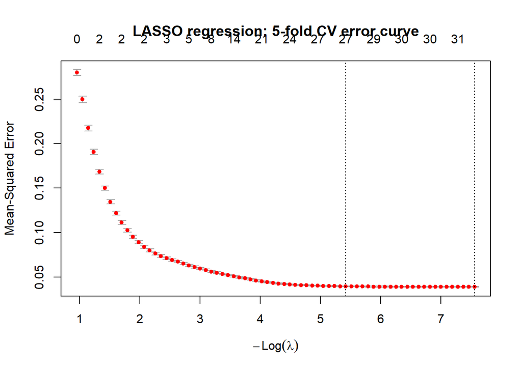

```r
cv_lasso <- cv.glmnet(
  x_train,
  y_train,
  alpha = 1,
  nfolds = 5
)

plot(cv_lasso)
title("LASSO regression: 5-fold CV error curve")
```

```r
lasso_lambda_min <- cv_lasso$lambda.min
lasso_lambda_1se <- cv_lasso$lambda.1se

lasso_lambda_min
lasso_lambda_1se
```

```
## [1] 0.0005207911
## [1] 0.004425441
```

```r
lasso_coef_min <- coef(cv_lasso, s = "lambda.min")
lasso_coef_1se <- coef(cv_lasso, s = "lambda.1se")

zero_predictors_min <- rownames(lasso_coef_min)[as.numeric(lasso_coef_min) == 0]
nonzero_predictors_min <- rownames(lasso_coef_min)[as.numeric(lasso_coef_min) != 0]

kable(
  extract_top_coefs(lasso_coef_min, top_n = 12),
  digits = 5,
  caption = "Largest LASSO coefficients at lambda.min"
)

zero_predictors_min
```

Largest LASSO coefficients at lambda.min

| term | estimate |
| --- | --- |
| zipcode_log_median | 0.62082 |
| lat | 0.40650 |
| waterfront1 | 0.38973 |
| grade5 | -0.36138 |
| grade4 | -0.34483 |
| long | -0.32608 |
| view4 | 0.30096 |
| grade6 | -0.23400 |
| grade12 | 0.20783 |
| grade13 | 0.19287 |
| grade11 | 0.17891 |
| view3 | 0.17428 |

```
## [1] "condition3" "grade8"
```

```r
pred_log_lasso_min <- predict(cv_lasso, s = "lambda.min", newx = x_test)
pred_log_lasso_1se <- predict(cv_lasso, s = "lambda.1se", newx = x_test)

lasso_test_min <- print_price_metrics(
  "LASSO model test metrics (lambda.min):",
  pred_log_lasso_min,
  test_df$price
)

lasso_test_1se <- print_price_metrics(
  "LASSO model test metrics (lambda.1se):",
  pred_log_lasso_1se,
  test_df$price
)
```

```
## LASSO model test metrics (lambda.min):
## RMSE: 142517.3
## R^2: 0.815552
##
## LASSO model test metrics (lambda.1se):
## RMSE: 143269.6
## R^2: 0.8136
```

### 5.2.1 LASSO interpretation

Unlike ridge, lasso can shrink some coefficients exactly to zero, which makes it a built-in variable-selection method. In the current presentation, lasso at `lambda.min` sets **`condition3`** and **`grade8`** to zero and achieves approximately **RMSE = 142,517** and **test $R^2 = 0.8156**.

# 6 5. Model comparison and final justification

The rubric asks for a direct comparison across subset, stepwise, ridge, and lasso methods. The table below compares the main held-out models. For the regularized methods, the primary comparison uses **`lambda.min`** because that corresponds to the minimum cross-validated error.

```r
comparison_table <- bind_rows(
  tibble(
    Method = "Best Subset (BIC)",
    Model_Size_or_Tuning = paste0("size = ", best_bic),
    RMSE = bss_test_metrics$RMSE,
    R2 = bss_test_metrics$R2
  ),
  tibble(
    Method = "Stepwise",
    Model_Size_or_Tuning = "both directions",
    RMSE = step_test_metrics$RMSE,
    R2 = step_test_metrics$R2
  ),
  tibble(
    Method = "Ridge",
    Model_Size_or_Tuning = paste0("lambda.min = ", signif(ridge_lambda_min, 5)),
    RMSE = ridge_test_min$RMSE,
    R2 = ridge_test_min$R2
  ),
  tibble(
    Method = "LASSO",
    Model_Size_or_Tuning = paste0("lambda.min = ", signif(lasso_lambda_min, 5)),
    RMSE = lasso_test_min$RMSE,
    R2 = lasso_test_min$R2
  )
) %>%
  arrange(RMSE)

kable(
  comparison_table,
  digits = 4,
  caption = "Final model comparison on the test set"
)
```

Final model comparison on the test set

| Method | Model_Size_or_Tuning | RMSE | R2 |
| --- | --- | --- | --- |
| Best Subset (BIC) | size = 27 | 142317.2 | 0.8161 |
| Ridge | lambda.min = 0.03849 | 142363.5 | 0.8159 |
| LASSO | lambda.min = 0.00052079 | 142517.3 | 0.8156 |
| Stepwise | both directions | 142518.0 | 0.8156 |

## 6.1 5.1 Final discussion

Overall, all four approaches are expected to perform very similarly on this dataset. That pattern is already visible in the current presentation, where the reported test-set performance is approximately: best subset **142,317 / 0.816**, ridge **142,363 / 0.816**, stepwise **142,518 / 0.8156**, and lasso **142,517 / 0.8156** for RMSE / test $R^2$, respectively.

The **BIC-selected best subset model** is the strongest final choice because it provides:

- the **lowest held-out RMSE** in the current results;
- a strong test $R^2$;
- an interpretable set of predictors centered on **location**, **living area**, **quality**, **view**, and **waterfront status**.

At the same time, the tiny differences across methods are important to mention: ridge is almost identical in predictive performance, which suggests the overall signal in the data is stable and not overly dependent on one modeling strategy. This is a useful point for the presentation because it shows that the findings are not fragile.

## 6.2 5.2 Overfitting and the role of cross-validation

Subset and stepwise procedures can overfit if model complexity is chosen only from training fit. That is why the project uses **BIC** for a stronger complexity penalty in best subset selection and **5-fold cross-validation** for ridge and lasso. Cross-validation helps estimate out-of-sample error and therefore improves generalization. The similarity between train-selected models and test-set results supports the conclusion that the final models are not severely overfit.

# 7 6. Classification extension

This project is a **regression** project with a continuous outcome, so the classification extension in the rubric is **not applicable here**. If the group later adds a binary classification target (for example, above-vs-below median price), then confusion matrix, sensitivity, specificity, ROC curve, and AUC could be included in a separate extension analysis. For the current submission, the core required work is the regression comparison.

# 8 7. Final conclusion

Sale price in the King County housing dataset is driven primarily by **location**, **home size**, **quality**, **waterfront access**, and **view-related amenities**. Across best subset, stepwise, ridge, and lasso, these same themes repeatedly emerge.

The final recommended model is the **BIC-selected best subset model** because it achieved the strongest test performance while remaining interpretable. Ridge and lasso confirm that the signal is stable under shrinkage, and 5-fold cross-validation provides additional protection against overfitting. This gives a strong, rubric-aligned justification for the final model choice.